### convolutional neural networks (CNN) on the MNIST dataset

```
library(keras)
library(ggplot2)
library(gridExtra)
```

深度學習中對圖像的識別能力，卷積神經網路(Convolutional Neural Networks, CNN)的表現可以說非常突出，以下連結有介紹[CNN的運作原理](https://brohrer.mcknote.com/zh-Hant/how_machine_learning_works/how_convolutional_neural_networks_work.html)，這篇以Keras實作CNN為主。Keras 對R使用者有 rstudio 的 [keras](https://rstudio.github.io/keras/index.html) 和 CRAN 的 [kerasR](https://cran.r-project.org/web/packages/kerasR/index.html) 介面可使用，我將利用前者練習實作，安裝步驟可參考連結。此外，由於Keras底層是TensorFlow ，下載安裝 [Python 3.5](https://www.python.org/downloads/release/python-353/) 是必要的，一切備妥後就可以開始使用R的keras套件，這次練習繼續使用 [MNIST 資料集](https://www.kaggle.com/c/digit-recognizer) ，以下是這次練習的CNN網路架構…

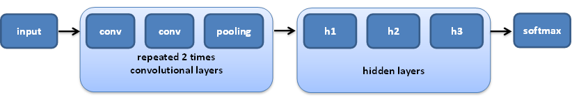

#### **Load and convert**

首先，載入42000筆訓練資料。其中80%(33600筆)拿來訓練，剩下的8400筆當做測試用

```r
train_data <- read.csv(file.path("data", "digit_recognizer","train.csv"), stringsAsFactors = F)
set.seed(777)
index <- sample(nrow(train_data), 0.8 * nrow(train_data))
train_dt <- train_data[index, ]
test_dt <- train_data[-index, ]
# train data
train_x <- train_dt[,-1]
train_y <-train_dt[,1]
# test data
test_x <- test_dt[,-1]
test_y <-test_dt[,1]
```

原始資料為灰階影像(28x28 pixels)，keras要求input資料需轉換為3維陣列，轉換後維度由原本的784變成28, 28, 1

```r
# 轉成array
train_x <- array(as.matrix(train_x), dim = c(nrow(train_x), 28, 28, 1))
test_x <- array(as.matrix(test_x), dim = c(nrow(test_x), 28, 28, 1))
# normalizing
train_x <- train_x / 255
test_x <- test_x / 255
dim(train_x)
```

```
## [1] 33600    28    28     1
```

```r
dim(test_x)
```

```
## [1] 8400   28   28    1
```

此外，本次練習目的為分類(標籤0~9)，配合keras需要將多類向量值轉成2進制矩陣，以測試資料前6筆為例，其中直欄[,1]表示0、[,2]表示1 … [,10]表示9

```r
# 標籤為多類向量,需轉換成2進制矩陣
train_y <- to_categorical(array(train_y), 10)
test_y <- to_categorical(array(test_y), 10)
head(test_y)
```

```
##      [,1] [,2] [,3] [,4] [,5] [,6] [,7] [,8] [,9] [,10]
## [1,]    0    1    0    0    0    0    0    0    0     0
## [2,]    1    0    0    0    0    0    0    0    0     0
## [3,]    0    0    0    0    0    1    0    0    0     0
## [4,]    0    0    0    1    0    0    0    0    0     0
## [5,]    0    0    0    0    0    0    0    0    0     1
## [6,]    0    0    1    0    0    0    0    0    0     0
```

#### **Define and configure**

設定輸入圖像的大小(input_shape)，梯度修正時處理的訓練樣本數(batch_size)，10個標籤值(num_classes)，迭代次數(epochs)

```r
# 設定參數
input_shape <- c(28, 28, 1)
batch_size <- 128
num_classes <- 10
epochs <- 50
```

本次model定義如下，共卷積4次來擷取特徵，filter sizes訂為3x3，feature maps個數自訂32、64、128、64，採線性整流單元(relu)激活函數避免極端值，簡化維度的池化使用2次，size為2x2，3層全連接的hidden layers…

```r
# 定義 model
model <- keras_model_sequential()
model %>%
  layer_conv_2d(filters = 32, kernel_size = c(3,3), activation = 'relu',
                input_shape = input_shape) %>%
  layer_conv_2d(filters = 64, kernel_size = c(3,3), activation = 'relu') %>%
  layer_max_pooling_2d(pool_size = c(2, 2)) %>%
  layer_conv_2d(filters = 128, kernel_size = c(3,3), activation = 'relu') %>%
  layer_conv_2d(filters = 64, kernel_size = c(3,3), activation = 'relu') %>%
  layer_max_pooling_2d(pool_size = c(2, 2)) %>%
  layer_dropout(rate = 0.25) %>%
  layer_flatten() %>%
  layer_dense(units = 256, activation = 'relu') %>%
  layer_dropout(rate = 0.5) %>%
  layer_dense(units = 256, activation = 'relu') %>%
  layer_dropout(rate = 0.3) %>%
  layer_dense(units = 128, activation = 'relu') %>%
  layer_dropout(rate = 0.3) %>%
  layer_dense(units = num_classes, activation = 'softmax')
```

配置訓練模型的目標函數、優化器及指標

```r
# 配置
model %>% compile(
  loss = 'categorical_crossentropy',
  optimizer = optimizer_adagrad(),
  metrics = c('accuracy')
)
```

#### **Train a Keras model**

根據上述設定參數開始訓練CNN模型(使用CPU執行,i3 4核執行約150分鐘)…model迭代結果指定至kerasCNN

```r
# 訓練model
kerasCNN <- model %>% fit(
  train_x,
  train_y,
  batch_size = batch_size,
  epochs = epochs,
  verbose = 1,
  validation_data = list(test_x, test_y)
)
```

#### **Evaluate and predict**

迭代50次得到的 accuracy 和 loss 如下

```r
# 效能評估
scores <- model %>% evaluate(
  test_x, test_y, verbose = 0
)
cat('Test accuracy:', scores[[2]], '\n')
cat('Test loss:', scores[[1]], '\n')
```

```
## Test accuracy: 0.9933333
```

```
## Test loss: 0.03677944
```

繪出迭代結果(kerasCNN)，本次實驗訓練與測試間預測誤差最小，在 accuracy 和 loss 都出現在第13次，表示此時model預測吻合度佳

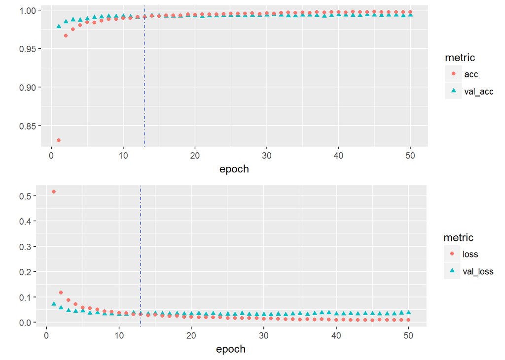

第13次迭代測試的accuracy 和 loss

```
##           epoch     score  metric
## val_acc13    13 0.9913095 val_acc
## acc13        13 0.9912202     acc
```

```
##            epoch      score   metric
## val_loss13    13 0.03458120 val_loss
## loss13        13 0.03078084     loss
```

accuracy最大出現在第31次迭代，loss最小則在第24次

```
##           epoch     score  metric
## val_acc31    31 0.9939286 val_acc
```

```
##            epoch      score   metric
## val_loss24    24 0.02942843 val_loss
```

本次CNN架構參數

```
## Model
## ___________________________________________________________________________
## Layer (type)                     Output Shape                  Param #
## ===========================================================================
## conv2d_5 (Conv2D)                (None, 26, 26, 32)            320
## ___________________________________________________________________________
## conv2d_6 (Conv2D)                (None, 24, 24, 64)            18496
## ___________________________________________________________________________
## max_pooling2d_3 (MaxPooling2D)   (None, 12, 12, 64)            0
## ___________________________________________________________________________
## conv2d_7 (Conv2D)                (None, 10, 10, 128)           73856
## ___________________________________________________________________________
## conv2d_8 (Conv2D)                (None, 8, 8, 64)              73792
## ___________________________________________________________________________
## max_pooling2d_4 (MaxPooling2D)   (None, 4, 4, 64)              0
## ___________________________________________________________________________
## dropout_5 (Dropout)              (None, 4, 4, 64)              0
## ___________________________________________________________________________
## flatten_2 (Flatten)              (None, 1024)                  0
## ___________________________________________________________________________
## dense_5 (Dense)                  (None, 256)                   262400
## ___________________________________________________________________________
## dropout_6 (Dropout)              (None, 256)                   0
## ___________________________________________________________________________
## dense_6 (Dense)                  (None, 256)                   65792
## ___________________________________________________________________________
## dropout_7 (Dropout)              (None, 256)                   0
## ___________________________________________________________________________
## dense_7 (Dense)                  (None, 128)                   32896
## ___________________________________________________________________________
## dropout_8 (Dropout)              (None, 128)                   0
## ___________________________________________________________________________
## dense_8 (Dense)                  (None, 10)                    1290
## ===========================================================================
## Total params: 528,842.0
## Trainable params: 528,842.0
## Non-trainable params: 0.0
## ___________________________________________________________________________
##
##
```

實際測試，使用小畫家手寫數字再裁剪成10個圖檔…

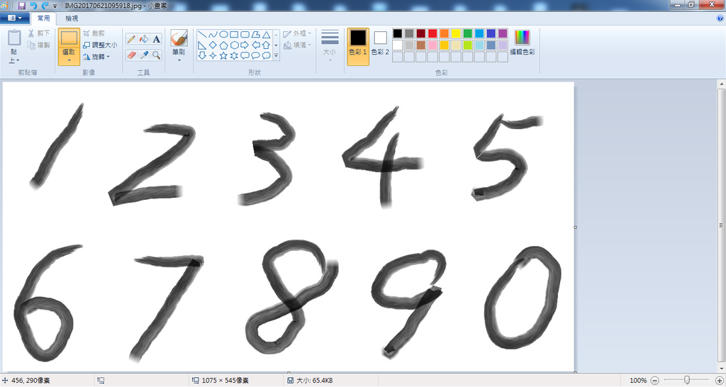

繪出8個隨選圖檔，然後再以model預測驗證…Good, 結果一致

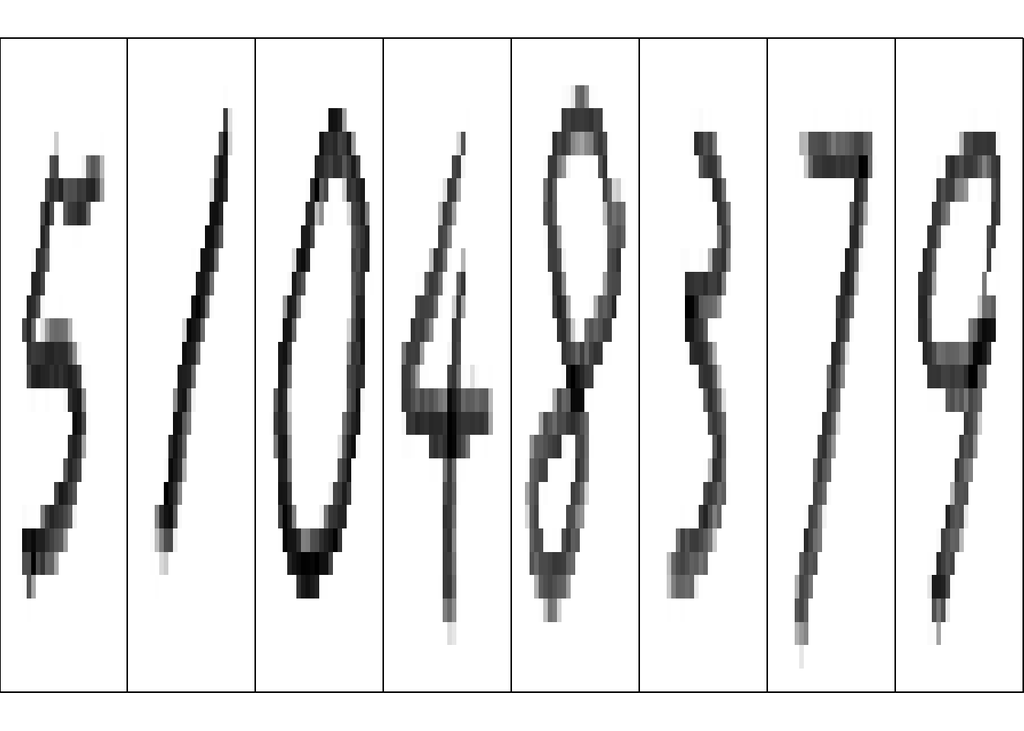

```r
#實際測試,隨選8個數字
img_num <- 8
testing <- sample(0:9, img_num)
img_mtx <- matrix(0,img_num, 784)

par(mar=c(2,0,2,0))
layout(matrix(1:(img_num * 1), 1, byrow = T))
for(i in seq_along(testing)){
  PIL = image_load(
    file.path("data", "digit_recognizer", paste0(testing[i], '.jpg')),
    grayscale = T,
    target_size = c(28, 28)
  )
  img_array = 255 - image_to_array(PIL, data_format = 'channels_last')
  img_array = t(img_array[1:28, , 1])
  #plot
  showDigit(img_array, "o")
  img_mtx[i,] <- as.vector(img_array)
}
```

```r
# 轉成array
img_mtx <- array(img_mtx, dim = c(nrow(img_mtx), 28, 28, 1))
img_mtx <- img_mtx / 255
# 預測
(pclasses <- model %>% predict_classes(img_mtx, batch_size = batch_size))
```

```
## [1] 5 1 0 4 8 3 7 9
```

#### **Summary**

這次練習使用Keras實作CNN，同樣使用MNIST資料集，在分類準確性上可以輕鬆達到99%以上，比起上次使用DNN來的好，不過由於多了convolutional layers，運算時間也較長。在[kaggle的排行榜](https://www.kaggle.com/c/digit-recognizer/leaderboard)上，目前若要進到100名以內的話，起碼要大於99.77%以上，我想除了調整架構、參數優化以外，結合Ensemble或許是個不錯的方法。除了CNN，Keras還有支援RNN、LSTM…這部份後續再花時間研究了

### Lessons Learned:

#### Convolutional Neural Networks (CNN)